# Introduction to Statistical Learning Chapter 8 Problem 10

Robert Smith

8/7/2017

# Exercises

## Applied

10. We now use boosting to predict `Salary` in the `Hitters` dataset.
1. Remove the observations for whom the salary information is unknown, and then log-transform the salaries

```r
library(ISLR)
data(Hitters)
Hitters<-Hitters[is.na(Hitters$Salary)==F,]
Hitters$Salary<-log(Hitters$Salary)
```

2. Create a training set to consider the first 200 observations, and a test set consisting of the remaining observations.

```r
train_set<-Hitters[1:200,]
test_set<-Hitters[201:nrow(Hitters),]
```

3. Perform boosting on the training set with 1,000 trees for a range of values of the shrinkage parameter, λ. Produce a plot with different shrinkage values on the x-axis and the corresponding training set MSE on the y-axis.

```r
library(gbm)
```

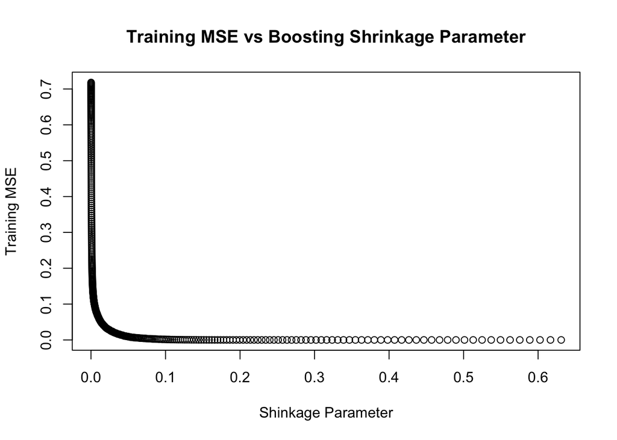

```r
train_MSE<-rep(NA,381)
test_MSE<-rep(NA,381)
mtry<-10^seq(-4,-.2,.01)
for (i in 1:length(mtry)){
set.seed(1)
boost_model<-gbm(Salary~.,data=train_set,distribution="gaussian",n.trees=1000,interaction.depth=4,shrinkage=mtry[i],verbose=F)
pred_values<-predict(boost_model,train_set,n.trees=1000)
train_MSE[i]<-mean((train_set$Salary-pred_values)^2)
pred_values<-predict(boost_model,test_set,n.trees=1000)
test_MSE[i]<-mean((test_set$Salary-pred_values)^2)
}
plot(mtry,train_MSE,type="b",xlab="Shinkage Parameter",ylab="Training MSE",main="Training MSE vs Boosting Shrinkage Parameter")
```

4. Produce a plot with different shrinkage values on the x-axis and the corresponding test set MSE on the y-axis.

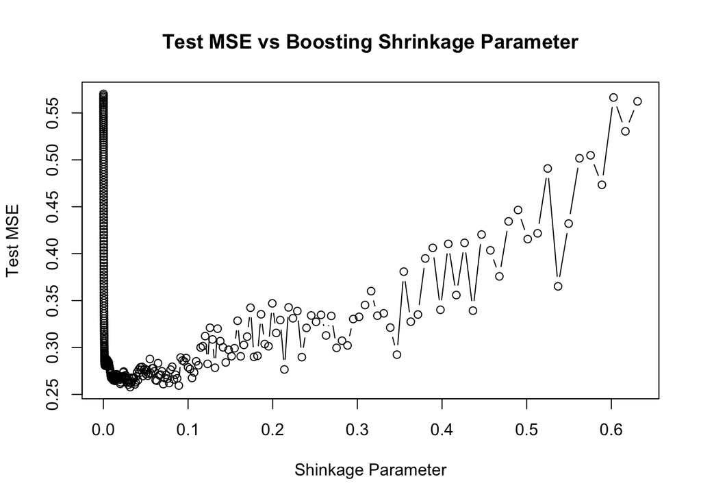

```r
plot(mtry,test_MSE,type="b",xlab="Shinkage Parameter",ylab="Test MSE",main="Test MSE vs Boosting Shrinkage Parameter")
```

5. Compare the test MSE of boosting to the test MSE that results from applying two of the regression approaches seen in Chapters 3 and 6.

Consider Basic Linear Regression

```r
linear_mod<-lm(Salary~.,data=train_set)
pred<-predict(linear_mod,test_set)
test_MSE<-mean((test_set$Salary-pred)^2)
print(test_MSE)
```

```
## [1] 0.4917959
```

Consider Lasso Regression with Cross-Validation

```r
library(glmnet)
set.seed(1234)
grid=10^seq(1,-3,length=100)
X_train<-model.matrix(Salary~.,data=train_set)[,-1]
X_test<-model.matrix(Salary~.,data=test_set)[,-1]

cv.lasso.mod=cv.glmnet(X_train,train_set$Salary,alpha=1,lambda=grid)
bestlam<-cv.lasso.mod$lambda.min

lasso_pred<-predict(cv.lasso.mod,s=bestlam,newx=X_test)
lasso.err<-mean((lasso_pred-test_set$Salary)^2)
print(lasso.err)
```

```
## [1] 0.4707941
```

Both methods have considerably higher error.

6. Which variables appear to be the most important predictors in the boosted model?

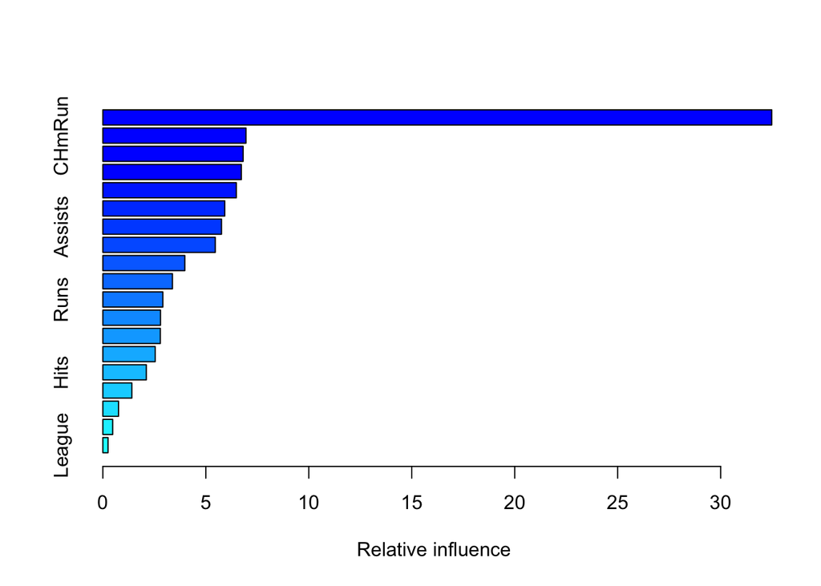

```
##                 var    rel.inf
## CAtBat       CAtBat 32.4816826
## CHmRun       CHmRun  6.9499202
## CRuns         CRuns  6.8111671
## AtBat         AtBat  6.7248328
## PutOuts     PutOuts  6.4802689
## Errors       Errors  5.9198829
## Assists     Assists  5.7613783
## Walks         Walks  5.4594504
## CWalks       CWalks  3.9800812
## HmRun         HmRun  3.3798930
## Runs           Runs  2.9130560
## CHits         CHits  2.7985919
## Years         Years  2.7912497
## RBI             RBI  2.5424662
## Hits           Hits  2.1102682
## CRBI           CRBI  1.4075221
## NewLeague NewLeague  0.7604336
## Division   Division  0.4772672
## League       League  0.2505876
```

```r
summary(boost_model)
```

CAtBat is by far the most important predictor in the boosted model, followed by CHmRun, CRuns, AtBat, and PutOuts variables that have nearly the same relative importance.

7. Now apply bagging to the training set. What is the test set MSE for this approach?

```r
library(randomForest)
set.seed(1234)
bag.tree_model<-randomForest(Salary~.,data=train_set,mtry=19,importance=T)

pred<-predict(bag.tree_model,test_set)
MSE<-mean((test_set$Salary-pred)^2)
print(paste("Bagged Test MSE:",round(MSE,3),sep=" "))
```

```
## [1] "Bagged Test MSE: 0.232"
```